# hw4

2023-12-06

Tuocheng Chen tchen465@wisc.edu

The successful attempts are pearson correlation and Euclidean distance.  
In fact as each time the cut dataframe is standardized (and the base data), the two standards are exactly the same!  
Let base be X and cut be Y.  
$\Sigma X_i^2 = n, \Sigma Y_i^2 = n, \Sigma X_i = 0, \Sigma Y_i = 0$.

Correlation is $\Sigma X_iY_i /n$, Euclidean is $\sqrt{2n-2\Sigma X_iY_i}$

I chose to use the Euclidean.

Used CHTC to run the R-script on all the tgz files, each with 1 job, and output a csv of its top 100,

merged all the results to get the top 100 of all files:hw4best100.csv.

Load the data and the csv and select the best 10. Plot them alongside the true data.

Rescaled the base and the fits to make the plots more obvious.

Difficulties: when transfer_input_files are incomplete, it does not run successfully.

Below are the plots

```r
rm(list=ls())
data <- read.csv("hw4best100.csv")
data = data[1:10,]
```

```r
#read in the fits files
best <- list()
number <- 10
lengths <- rep(0,number)
for (j in 1:number){
  best[[j]] <- readFrameFromFITS(paste("./data/",data$spectrumID[j],sep=""))
  best[[j]]$index <- 1:nrow(best[[j]])
}
base <- readFrameFromFITS("./data/cB58_Lyman_break.fit")
colnames(base)<-c("loglam","flux")
base$index <- 1:nrow(base)
```

```r
# Define plotting function
myplot <- function(j) {
  #adjust the scales
  # both mean 0
  #same var as sample
    bestflux = best[[j]]
    base1 <- base
    m1 = mean(bestflux$flux)
    s1 = sd(bestflux$flux)
    m2 = mean(base1$flux)
    s2 = sd(base1$flux)
    bestflux$flux = (bestflux$flux - m1)/s1
    base1$flux = (base1$flux - m2)/s2

    spectrumID <- sub("^[0-9]{4}/", "", gsub("\\.fits$", "", data$spectrumID[j]))
    plot(bestflux$flux, type = "l", col = "blue", xlab = "Index", ylab = "Rescaled Flux",
         main = paste("cB58 and ", spectrumID, sep = ""), xlim = c(1, nrow(bestflux)), ylim=c(-4,4))
    lines(seq(data$i[j], data$i[j] + length(base1$flux) - 1), base1$flux, type = "l", col = "red")
    legend("topright", legend = c(spectrumID, "cB58"), col = c("blue", "red"), lty = 1)
}
```

Use `myplot(i)` to plot the i th plot. Order adjusted to 2-1-3-5-7-4-6-8-9-10

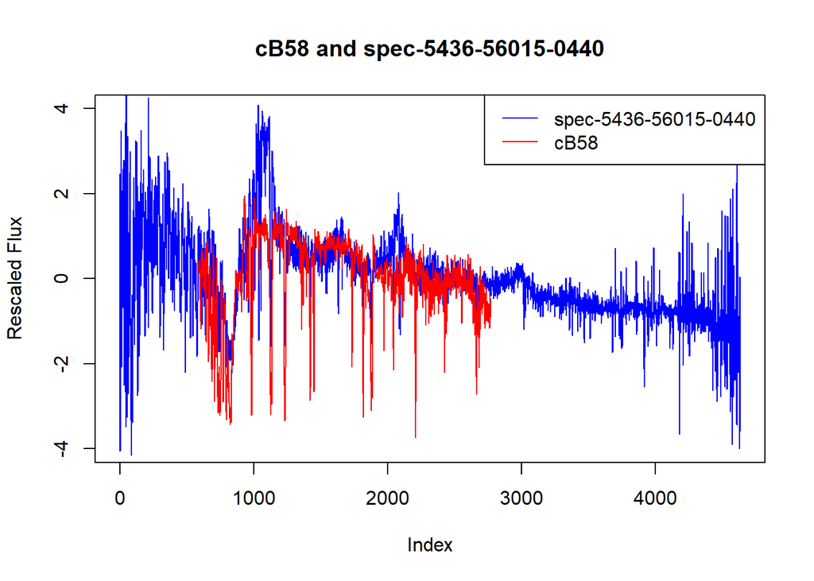

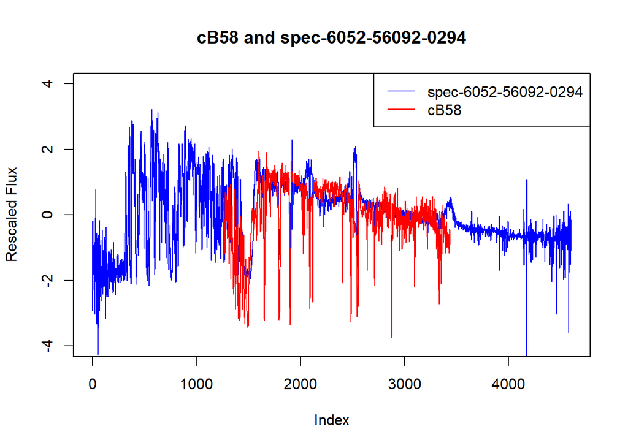

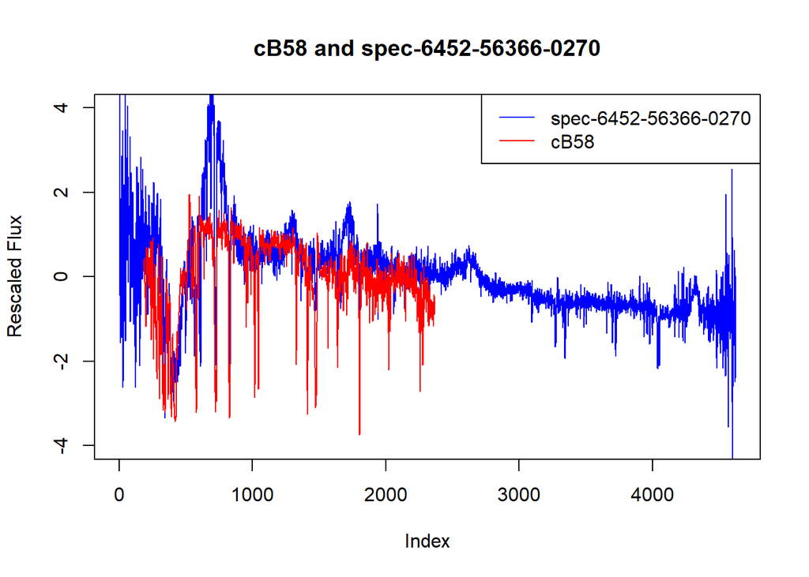

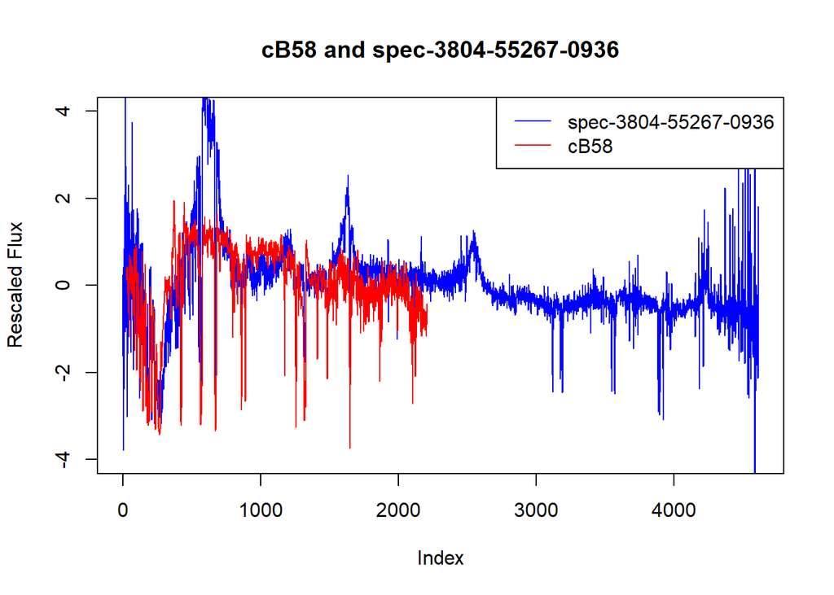

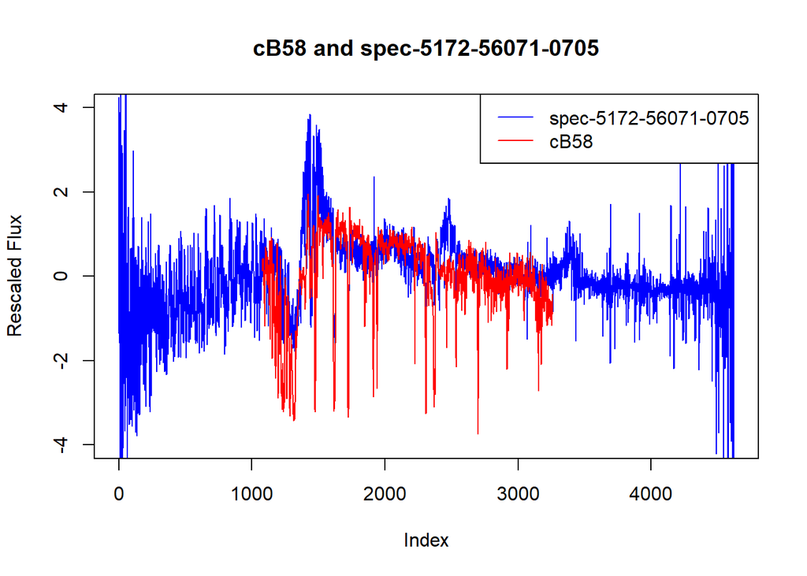

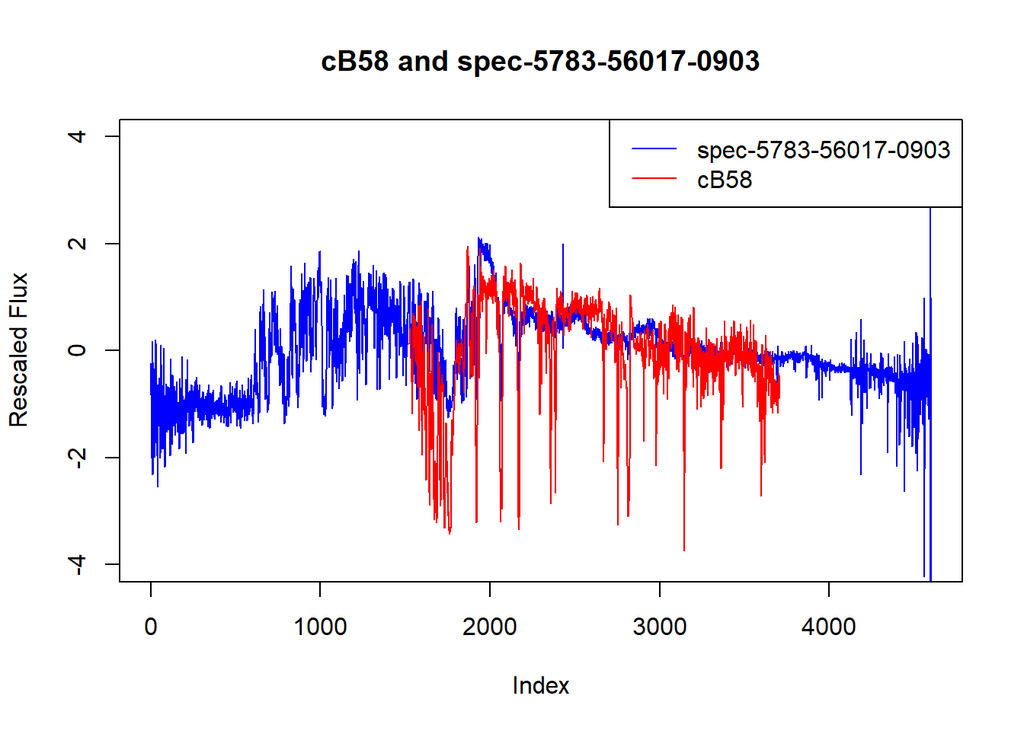

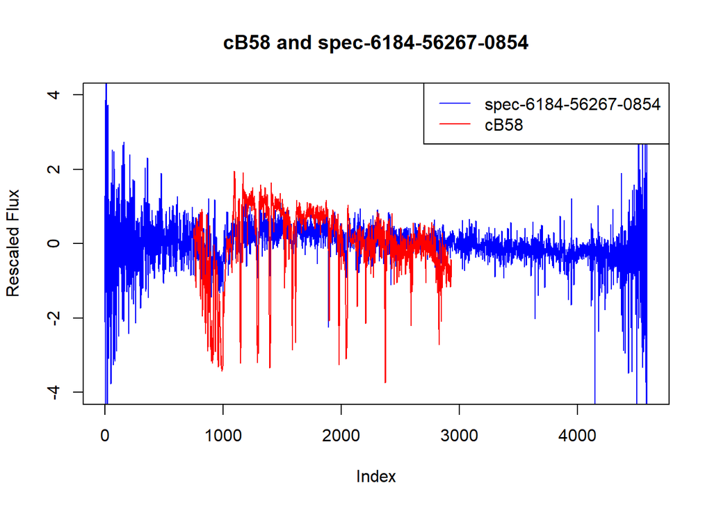

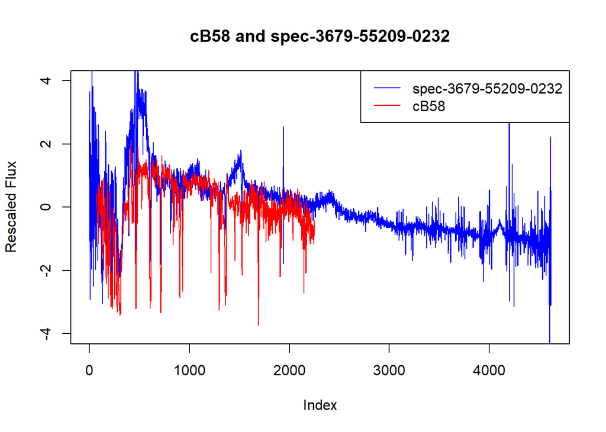

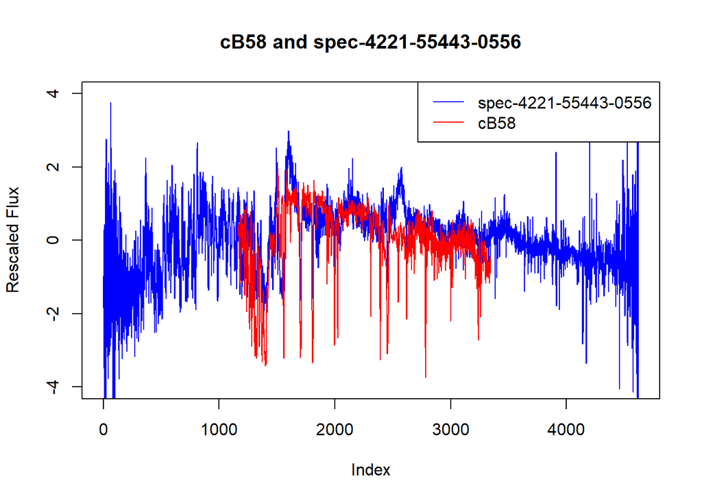

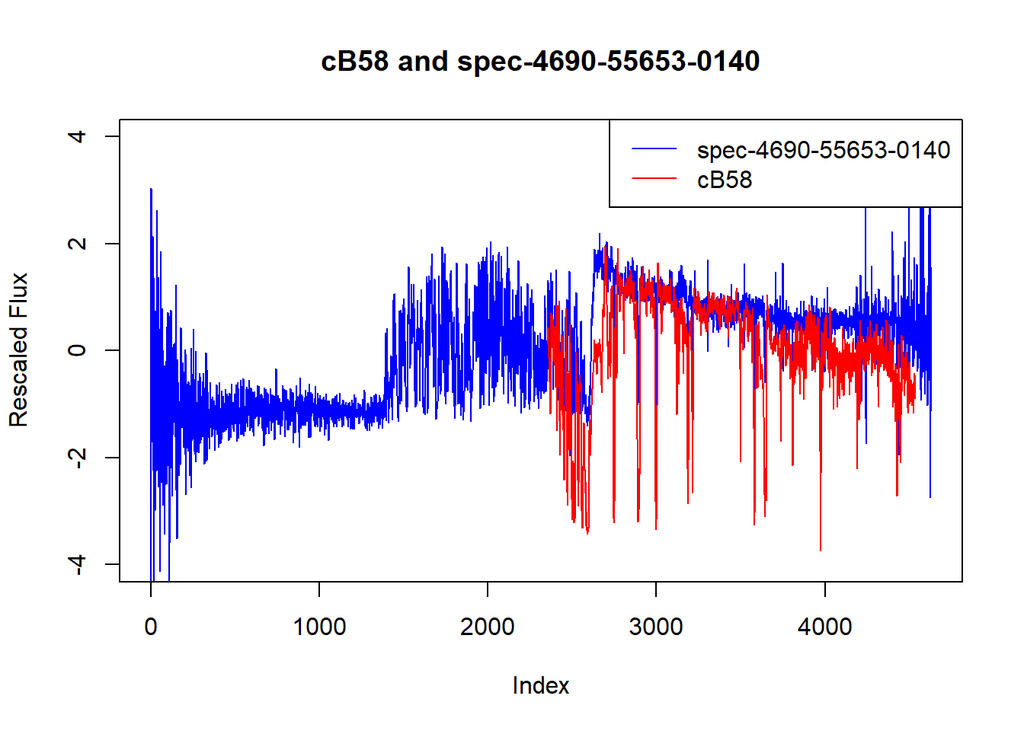